# Regression analysis

Evgenii Berdinskikh, Marina Kozyreva, Anton Tikhonenko

2025-02-08

## Data import

```r
## Ambulance Data related to acute cerebrovascular accidents
brain_data <- read_csv("data/raw/brain_data.csv") %>%
   mutate(across(c(Year, Season, Month, DayOff, COVID, Sudden_Start, Dst_level), as.factor))
## Ambulance Long Data related to acute cerebrovascular accidents
brain_data_long <- read_csv("data/raw/brain_data_long.csv") %>%
    mutate(across(c(Year, Season, Month, DayOff, COVID, Sudden_Start, Dst_level, Sex, Age), as.factor))
```

## Basic model

The distribution of ambulance calls follows a Poisson distribution, as observed in the graph:

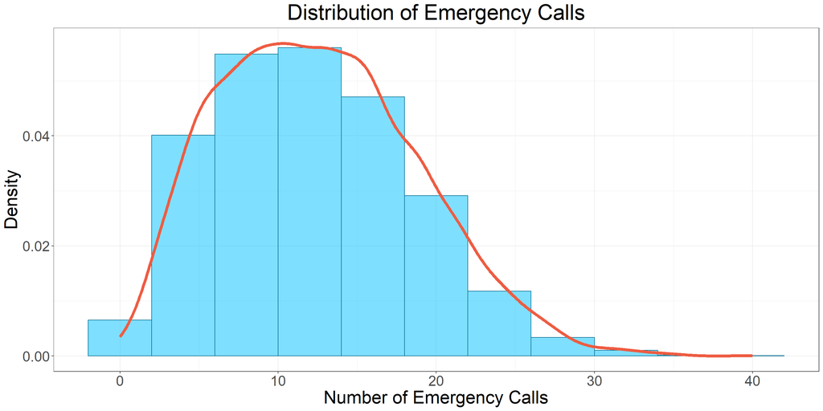

```r
brain_data %>%
  ggplot(aes(x = EMS, after_stat(density) )) +
  geom_histogram(binwidth = 4, fill = "deepskyblue", colour = "deepskyblue4", alpha = 0.5) +
  geom_density(color = "tomato2", linewidth = 2) +
  theme_custom +
  labs(x = "Number of Emergency Calls",
       y = "Density",
       title = "Distribution of Emergency Calls") +
  theme_custom
```

The baseline Poisson regression model included the date, average daily temperature, number of sunspots, and the total Kp index for the day. All coefficients are significant, p < 0.05.

```r
poisson_m0 <- glm(EMS ~ Date + Temp_mean + Sunspots + Kp_Sum,
    data = brain_data, family = poisson)

poisson_m0 %>% summary()
```

```
##
## Call:
## glm(formula = EMS ~ Date + Temp_mean + Sunspots + Kp_Sum, family = poisson,
##     data = brain_data)
##
## Coefficients:
##               Estimate Std. Error z value Pr(>|z|)
## (Intercept) -1.217e+00  4.098e-02 -29.694  < 2e-16 ***
## Date         2.253e-04  2.369e-06  95.102  < 2e-16 ***
## Temp_mean   -9.858e-04  2.727e-04  -3.614 0.000301 ***
## Sunspots     2.969e-04  8.624e-05   3.443 0.000575 ***
## Kp_Sum      -1.138e-03  4.874e-04  -2.334 0.019587 *
## ---
## Signif. codes:  0 '***' 0.001 '**' 0.01 '*' 0.05 '.' 0.1 ' ' 1
##
## (Dispersion parameter for poisson family taken to be 1)
##
##     Null deviance: 18524.4  on 5736  degrees of freedom
## Residual deviance:  8993.4  on 5732  degrees of freedom
## AIC: 33266
##
## Number of Fisher Scoring iterations: 4
```

## Basic model diagnostic

The diagnostic plots and component-plus-residual plots do not reveal any major violations in the model, confirming its adequacy.

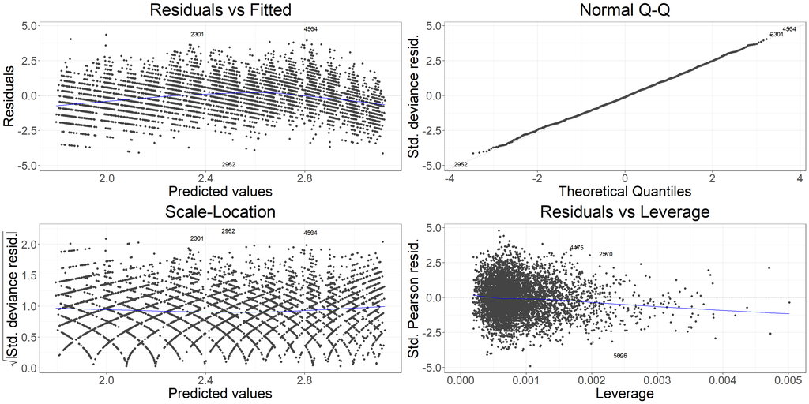

```r
autoplot(poisson_m0)+theme_custom
```

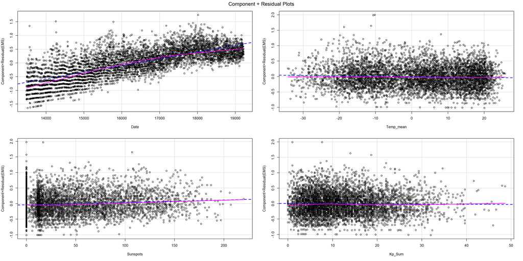

```r
crPlots(poisson_m0)
```

However, overdispersion **(1.54)** and autocorrelation of residuals are present, which may indicate the need for model refinement.

```r
# Overdispersion
dispersiontest(poisson_m0)
```

```
##
##  Overdispersion test
##
## data:  poisson_m0
## z = 18.682, p-value < 2.2e-16
## alternative hypothesis: true dispersion is greater than 1
## sample estimates:
## dispersion
##   1.543548
```

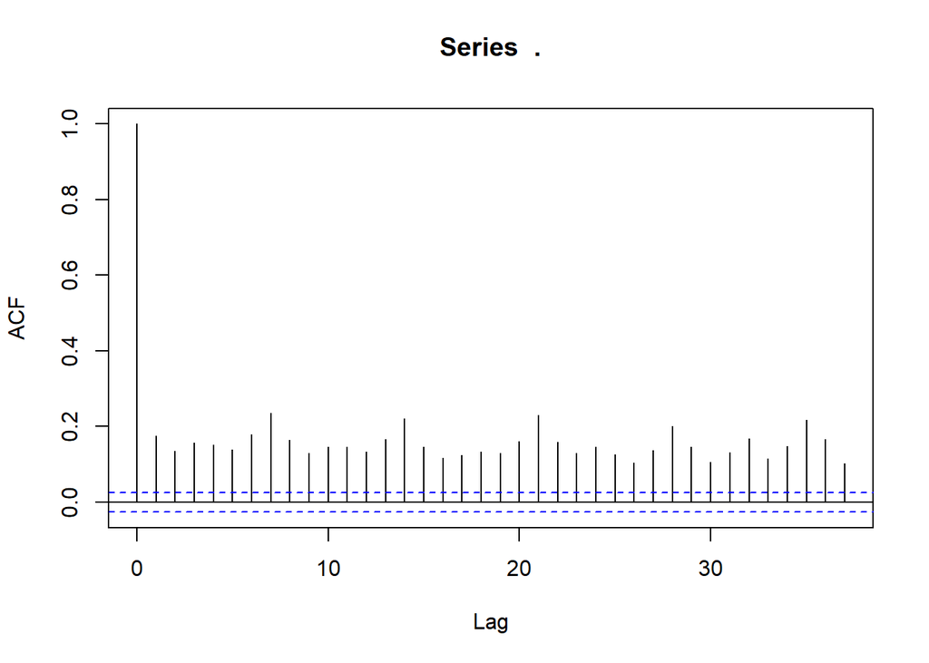

```r
# Autocorrelation of residuals
residuals(poisson_m0, type = "response") %>% acf()
```

## Alternative models

As an alternative, we considered negative binomial regression and the use of robust standard errors for the Poisson regression.

```r
# Poisson regression
tidy(poisson_m0, conf.level = 0.95, conf.int = TRUE) %>%
  mutate(
    model = "Poisson",
    EMS_effect = ifelse(
    term != "(Intercept)",
    paste0(signif((exp(estimate) - 1) * 100, 3), "%"),
    signif((exp(estimate)), 3))) -> Poisson_data

# Heteroscedasticity-consistent estimation  (vcovHC)
bind_cols(
  tidy(coeftest(poisson_m0, vcov. = vcovHC(poisson_m0, type = "HC3"))),
  coefci(poisson_m0, vcov. = vcovHC(poisson_m0, type = "HC3")) %>%
    as_tibble() %>% rename(conf.low = "2.5 %", conf.high = "97.5 %")) %>%
  mutate(
    model = "Poisson_vcovHC",
    EMS_effect = ifelse(
    term != "(Intercept)",
    paste0(signif((exp(estimate) - 1) * 100, 3), "%"),
    signif((exp(estimate)), 3))) -> Poisson_vcovHC_data

# Heteroscedasticity and Autocorrelation Consistent estimation (vcovHAC)
bind_cols(
  tidy(coeftest(poisson_m0, vcov. = vcovHAC(poisson_m0))),
  coefci(poisson_m0, vcov. = vcovHAC(poisson_m0)) %>%
    as_tibble() %>% rename(conf.low = "2.5 %", conf.high = "97.5 %")) %>%
  mutate(
    model = "Poisson_vcovHAC",
    EMS_effect = ifelse(
    term != "(Intercept)",
    paste0(signif((exp(estimate) - 1) * 100, 3), "%"),
    signif((exp(estimate)), 3))) -> Poisson_vcovHAC_data

# Negative binomial regression
NBR_model <- glm.nb(EMS ~ Date + Temp_mean + Sunspots + Kp_Sum,
                    data = brain_data, link = "log")

tidy(NBR_model, conf.level = 0.95, conf.int = TRUE) %>%
  mutate(
    model = "Neg_binomial",
    EMS_effect = ifelse(
    term != "(Intercept)",
    paste0(signif((exp(estimate) - 1) * 100, 3), "%"),
    signif((exp(estimate)), 3))) -> Neg_binomial_data
```

The use of robust standard errors (vcovHC/vcovHAC) and negative binomial regression significantly increases the confidence interval for the estimates. This further highlights the need to improve the Poisson model to address overdispersion and autocorrelation.

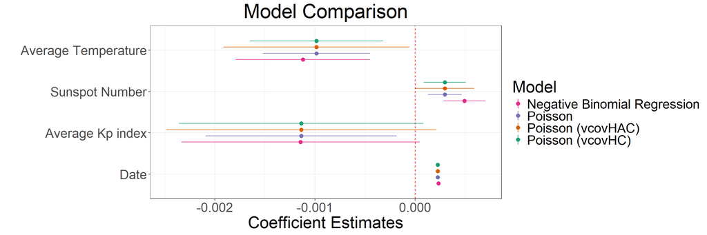

```r
bind_rows(Poisson_data, Poisson_vcovHC_data, Poisson_vcovHAC_data, Neg_binomial_data) %>%
  filter(term != "(Intercept)") %>%
  mutate(term = fct_recode(term, `Sunspot Number` = "Sunspots",
                           `Average Temperature` = "Temp_mean",
                           `Average Kp index` = "Kp_Sum"),
         model = fct_recode(model, `Poisson (vcovHC)` = "Poisson_vcovHC",
                           `Poisson (vcovHAC)`= "Poisson_vcovHAC",
                           `Negative Binomial Regression` = "Neg_binomial")) %>%
  ggplot(aes(x = term,y = estimate, ymin = conf.low, ymax = conf.high, colour = model))+
  geom_pointrange(position = position_dodge(width = 0.6)) +
  geom_hline(yintercept = 0, linetype = "dashed", color = "red") +
  scale_color_brewer(palette = "Dark2", direction = -1)+
  coord_flip() +
  labs( x = "", y = "Coefficient Estimates", title = "Model Comparison", color = "Model") +
  theme_custom
```

## Week lag

According to the ACF, spikes occur with a 7-day periodicity. We plan to address this by adding the **day of the week**! The ANOVA shows that including the new term significantly improves the model’s explanatory power. The lags have been aligned, but their overall reduction still requires further adjustment.

```r
brain_data_transform <- brain_data %>%
  mutate(Day_Week = factor(weekdays(Date),
                           levels = c("Monday", "Tuesday", "Wednesday", "Thursday",
                                      "Friday", "Saturday", "Sunday")))

poisson_m1 <- glm(EMS ~ Date + Day_Week + Temp_mean + Sunspots + Kp_Sum,
                               data = brain_data_transform, family = poisson)

anova(poisson_m0, poisson_m1, test = "LR")
```

```
## Analysis of Deviance Table
##
## Model 1: EMS ~ Date + Temp_mean + Sunspots + Kp_Sum
## Model 2: EMS ~ Date + Day_Week + Temp_mean + Sunspots + Kp_Sum
##   Resid. Df Resid. Dev Df Deviance  Pr(>Chi)
## 1      5732     8993.4
## 2      5726     8375.4  6   617.99 < 2.2e-16 ***
## ---
## Signif. codes:  0 '***' 0.001 '**' 0.01 '*' 0.05 '.' 0.1 ' ' 1
```

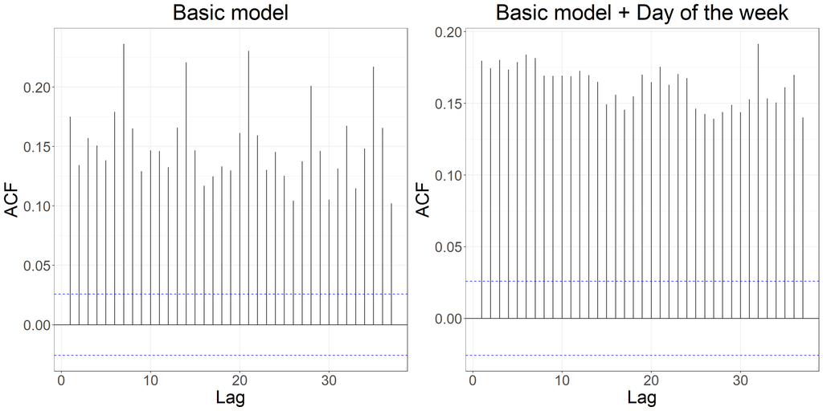

```r
ggarrange (
residuals(poisson_m0, type = "response") %>% acf() %>% autoplot() +
  ggtitle("Basic model") + theme_custom,
residuals(poisson_m1, type = "response") %>% acf() %>% autoplot() +
  ggtitle("Basic model + Day of the week") + theme_custom
)
```

## Age & Gender

```r
brain_data_long_transform <- brain_data_long %>%
  mutate(Day_Week = factor(weekdays(Date),
                           levels = c("Monday", "Tuesday", "Wednesday", "Thursday",
                                      "Friday", "Saturday", "Sunday")))

poisson_m2 <- glm(EMS ~ Date + Day_Week + Temp_mean + Sunspots + Kp_Sum + Age + Sex,
                  data = brain_data_long_transform, family = poisson)
```

The inclusion of new variables **(gender and age)** in the model, using the long format data **(1 day = 6 rows)**, reduced overdispersion from 1.54 to 1.20. The ACF drops sharply, but spikes persist at every 6th row!

```r
# Overdispersion
dispersiontest(poisson_m0)
```

```
##
##  Overdispersion test
##
## data:  poisson_m0
## z = 18.682, p-value < 2.2e-16
## alternative hypothesis: true dispersion is greater than 1
## sample estimates:
## dispersion
##   1.543548
```

```r
 dispersiontest(poisson_m2)
```

```
##
##  Overdispersion test
##
## data:  poisson_m2
## z = 18.414, p-value < 2.2e-16
## alternative hypothesis: true dispersion is greater than 1
## sample estimates:
## dispersion
##   1.195742
```

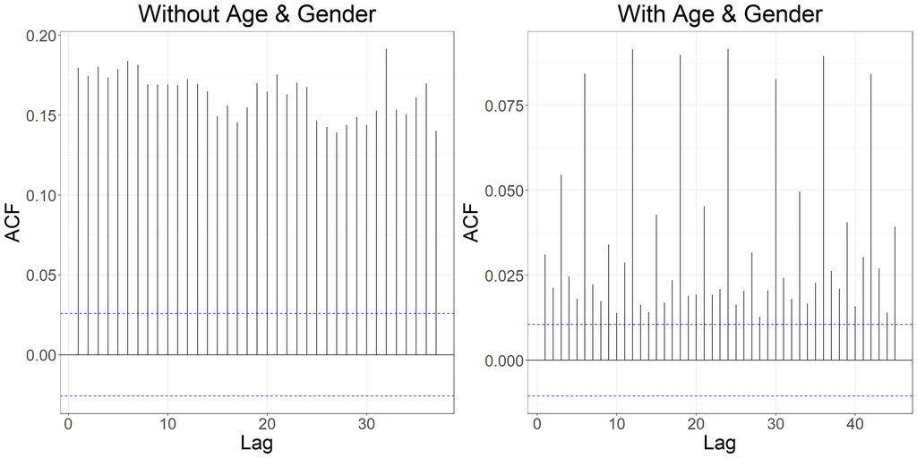

```r
# Autocorrelation of residuals
ggarrange (
residuals(poisson_m1, type = "response") %>% acf() %>% autoplot() +
  ggtitle("Without Age & Gender") + theme_custom,
residuals(poisson_m2, type = "response") %>% acf() %>% autoplot() +
  ggtitle("With Age & Gender") + theme_custom
)
```

Replacing **(Age + Sex)** with their interaction **(Age * Sex)** shows an improvement in the model, as indicated by the ANOVA. Additionally, the lags are now more evenly distributed.

```r
poisson_m3 <- glm(EMS ~ Date + Day_Week + Age*Sex + Temp_mean + Sunspots + Kp_Sum,
                               data = brain_data_long_transform, family = poisson)

anova(poisson_m2, poisson_m3)
```

```
## Analysis of Deviance Table
##
## Model 1: EMS ~ Date + Day_Week + Temp_mean + Sunspots + Kp_Sum + Age +
##     Sex
## Model 2: EMS ~ Date + Day_Week + Age * Sex + Temp_mean + Sunspots + Kp_Sum
##   Resid. Df Resid. Dev Df Deviance  Pr(>Chi)
## 1     34408      42057
## 2     34406      41176  2   881.28 < 2.2e-16 ***
## ---
## Signif. codes:  0 '***' 0.001 '**' 0.01 '*' 0.05 '.' 0.1 ' ' 1
```

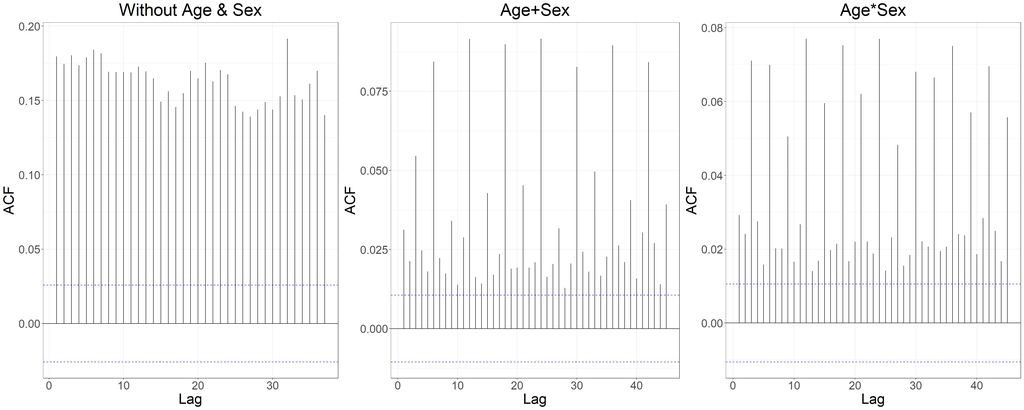

```r
# Autocorrelation of residuals
ggarrange (
residuals(poisson_m1, type = "response") %>% acf() %>% autoplot() +
  ggtitle("Without Age & Sex") + theme_custom,
residuals(poisson_m2, type = "response") %>% acf() %>% autoplot() +
  ggtitle("Age+Sex") + theme_custom,
residuals(poisson_m3, type = "response") %>% acf() %>% autoplot() +
  ggtitle("Age*Sex") + theme_custom, nrow = 1
)
```

## Calendar effect

Adding variables for **DayOff** and **COVID** shows meaningful improvements in the model, as confirmed by the ANOVA.

```r
# workdays vs weekend
poisson_m4 <- glm(EMS ~ Date + Day_Week + DayOff + Age*Sex +
                        Temp_mean + Sunspots + Kp_Sum,
                               data = brain_data_long_transform, family = poisson)

anova(poisson_m3, poisson_m4, test = "LR")
```

```
## Analysis of Deviance Table
##
## Model 1: EMS ~ Date + Day_Week + Age * Sex + Temp_mean + Sunspots + Kp_Sum
## Model 2: EMS ~ Date + Day_Week + DayOff + Age * Sex + Temp_mean + Sunspots +
##     Kp_Sum
##   Resid. Df Resid. Dev Df Deviance  Pr(>Chi)
## 1     34406      41176
## 2     34405      41065  1    110.8 < 2.2e-16 ***
## ---
## Signif. codes:  0 '***' 0.001 '**' 0.01 '*' 0.05 '.' 0.1 ' ' 1
```

```r
# COVID-19
poisson_m5 <- glm(EMS ~ Date + Day_Week + DayOff + COVID + Age*Sex +
                        Temp_mean + Sunspots + Kp_Sum,
                               data = brain_data_long_transform, family = poisson)

anova(poisson_m4, poisson_m5, test = "LR")
```

```
## Analysis of Deviance Table
##
## Model 1: EMS ~ Date + Day_Week + DayOff + Age * Sex + Temp_mean + Sunspots +
##     Kp_Sum
## Model 2: EMS ~ Date + Day_Week + DayOff + COVID + Age * Sex + Temp_mean +
##     Sunspots + Kp_Sum
##   Resid. Df Resid. Dev Df Deviance  Pr(>Chi)
## 1     34405      41065
## 2     34404      40354  1   710.49 < 2.2e-16 ***
## ---
## Signif. codes:  0 '***' 0.001 '**' 0.01 '*' 0.05 '.' 0.1 ' ' 1
```

## Cyclic component

The additional variable accounts for the cyclic nature of the data and synchronizes it with the temperature.

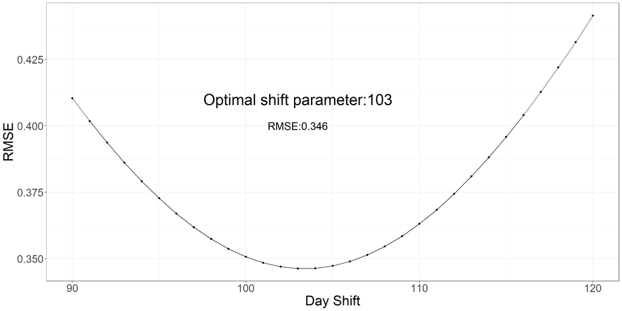

```r
brain_data_long_transform <- brain_data_long_transform %>%
  mutate(Temp_scaled = scale(Temp_mean),
         Sin_year = sin(2 * pi * (yday(Date) - 103) / 365.25))

# RMSE function
RMSE_function <- function(shift) {
  brain_data_long_transform %>%
    mutate(
      Sin_year = sin(2 * pi * (yday(Date) - shift) / 365.25),
      Sin_year_scaled = scale(Sin_year),
      Squared_Error = (Temp_scaled - Sin_year_scaled)^2 ) %>%
    summarise(RMSE = sqrt(mean(Squared_Error, na.rm = TRUE))) %>%
    pull(RMSE)
}

# Phase-shift search
shifts <- 90:120
RMSE_values <- sapply(shifts, RMSE_function)

tibble(Shift = shifts, RMSE = RMSE_values) %>%
  ggplot(aes(x = Shift, y = RMSE)) +
  geom_line() +
  geom_point() +
  labs(x = "Day Shift", y = "RMSE") +
  theme_custom +
  annotate("text", x = 103, y = 0.41, size = 10,
           label = paste0("Optimal shift parameter:", shifts[which.min(RMSE_values)]))+
  annotate("text", x = 103, y = 0.40, size = 7,
           label = paste0("RMSE:", round(min(RMSE_values), 3)))
```

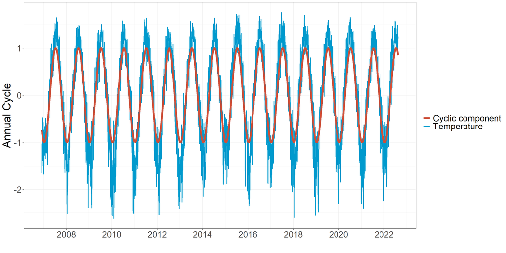

```r
  brain_data_long_transform %>%
    ggplot(aes(x = Date)) +
  geom_line(aes(y = Temp_scaled, color = "Temperature"), linewidth = 1) +
  geom_line(aes(y = Sin_year, color = "Cyclic component"), linewidth = 2)+
  scale_color_manual(values = c("Temperature" = "deepskyblue3", "Cyclic component" = "tomato3")) +
  scale_x_date(date_breaks = "2 year", date_labels = "%Y")+
  labs(x = "", y = "Annual Cycle", colour = "")+
  theme_custom
```

Adding the Cyclic Component, according to the ANOVA analysis, improves the model.

```r
poisson_m6 <- glm(EMS ~ Date + Day_Week + DayOff + COVID + Sin_year +
                        Temp_mean + Sunspots + Kp_Sum + Age*Sex,
                               data = brain_data_long_transform, family = poisson)

anova(poisson_m5, poisson_m6, test = "LR")
```

```
## Analysis of Deviance Table
##
## Model 1: EMS ~ Date + Day_Week + DayOff + COVID + Age * Sex + Temp_mean +
##     Sunspots + Kp_Sum
## Model 2: EMS ~ Date + Day_Week + DayOff + COVID + Sin_year + Temp_mean +
##     Sunspots + Kp_Sum + Age * Sex
##   Resid. Df Resid. Dev Df Deviance Pr(>Chi)
## 1     34404      40354
## 2     34403      40344  1   10.188 0.001413 **
## ---
## Signif. codes:  0 '***' 0.001 '**' 0.01 '*' 0.05 '.' 0.1 ' ' 1
```

## Geomagnetic parameters

Replacing the daily Kp index with the **local K index** for Irkutsk reduces the AIC, confirming the choice of the local index. ANOVA also showed that adding the **Dst index** as the daily amplitude of values improves the model, while adding the presence of **Sudden Impulses** had no significant impact.

```r
# K index (IRT)
poisson_m7 <- glm(EMS ~ Date + Day_Week + DayOff + COVID + Sin_year +
                        Temp_mean + Sunspots + K_Sum + Age*Sex,
                               data = brain_data_long_transform, family = poisson)
AIC(poisson_m6, poisson_m7)
```

```
##            df      AIC
## poisson_m6 19 102282.6
## poisson_m7 19 101855.4
```

```r
# Dst index (Dst_var)
poisson_m8 <- glm(EMS ~ Date + Day_Week + DayOff + COVID + Sin_year +
                        Temp_mean + Sunspots + K_Sum + Dst_mean + Age*Sex,
                               data = brain_data_long_transform, family = poisson)
poisson_m9 <- glm(EMS ~ Date + Day_Week + DayOff + COVID + Sin_year +
                        Temp_mean + Sunspots + K_Sum + Dst_var + Age*Sex,
                               data = brain_data_long_transform, family = poisson)
poisson_m10 <- glm(EMS ~ Date + Day_Week + DayOff + COVID + Sin_year +
                        Temp_mean + Sunspots + K_Sum + Dst_level + Age*Sex,
                               data = brain_data_long_transform, family = poisson)
anova(poisson_m7, poisson_m8, test = "LR")
```

```
## Analysis of Deviance Table
##
## Model 1: EMS ~ Date + Day_Week + DayOff + COVID + Sin_year + Temp_mean +
##     Sunspots + K_Sum + Age * Sex
## Model 2: EMS ~ Date + Day_Week + DayOff + COVID + Sin_year + Temp_mean +
##     Sunspots + K_Sum + Dst_mean + Age * Sex
##   Resid. Df Resid. Dev Df Deviance Pr(>Chi)
## 1     34259      40182
## 2     34258      40181  1   1.1573    0.282
```

```r
anova(poisson_m7, poisson_m9, test = "LR")
```

```
## Analysis of Deviance Table
##
## Model 1: EMS ~ Date + Day_Week + DayOff + COVID + Sin_year + Temp_mean +
##     Sunspots + K_Sum + Age * Sex
## Model 2: EMS ~ Date + Day_Week + DayOff + COVID + Sin_year + Temp_mean +
##     Sunspots + K_Sum + Dst_var + Age * Sex
##   Resid. Df Resid. Dev Df Deviance Pr(>Chi)
## 1     34259      40182
## 2     34258      40175  1   7.8316 0.005134 **
## ---
## Signif. codes:  0 '***' 0.001 '**' 0.01 '*' 0.05 '.' 0.1 ' ' 1
```

```r
anova(poisson_m7, poisson_m10, test = "LR")
```

```
## Analysis of Deviance Table
##
## Model 1: EMS ~ Date + Day_Week + DayOff + COVID + Sin_year + Temp_mean +
##     Sunspots + K_Sum + Age * Sex
## Model 2: EMS ~ Date + Day_Week + DayOff + COVID + Sin_year + Temp_mean +
##     Sunspots + K_Sum + Dst_level + Age * Sex
##   Resid. Df Resid. Dev Df Deviance Pr(>Chi)
## 1     34259      40182
## 2     34255      40175  4   7.0946    0.131
```

```r
# Sudden_Start (-)
poisson_m11 <- glm(EMS ~ Date + Day_Week + DayOff + COVID + Sin_year +
                        Temp_mean + Sunspots + K_Sum + Dst_var + Sudden_Start + Age*Sex,
                               data = brain_data_long_transform, family = poisson)
anova(poisson_m9, poisson_m11, test = "LR")
```

```
## Analysis of Deviance Table
##
## Model 1: EMS ~ Date + Day_Week + DayOff + COVID + Sin_year + Temp_mean +
##     Sunspots + K_Sum + Dst_var + Age * Sex
## Model 2: EMS ~ Date + Day_Week + DayOff + COVID + Sin_year + Temp_mean +
##     Sunspots + K_Sum + Dst_var + Sudden_Start + Age * Sex
##   Resid. Df Resid. Dev Df Deviance Pr(>Chi)
## 1     34258      40175
## 2     34257      40175  1 0.095171   0.7577
```

## Sunspots

Solar activity was additionally assessed by the absolute difference between Sunspots and the average Sunspots value over the 24th solar cycle. No significant difference was found between this model and the model with Sunspots.

```r
brain_data %>%
  filter(between(Date, as.Date("2008-12-15"),  as.Date("2019-12-15"))) %>%
  pull(Sunspots) %>% mean() -> Solar_cycle_mean

brain_data_long_transform <- brain_data_long_transform %>%
  mutate(Sunspots_dev = abs(Sunspots - mean(Solar_cycle_mean)))

poisson_m12 <- glm(EMS ~ Date + Day_Week + DayOff + COVID + Sin_year +
                        Temp_mean +  Sunspots_dev + K_Sum + Dst_var + Age*Sex,
                               data = brain_data_long_transform, family = poisson)

AIC(poisson_m9, poisson_m12)
```

```
##             df      AIC
## poisson_m9  20 101849.5
## poisson_m12 20 101855.5
```

## Climatic

When additional climate data were included, ANOVA indicated that the variable **Wind** is significant for the model, while precipitation did not show a significant effect.

```r
poisson_m13 <- glm(EMS ~ Date + Day_Week + DayOff + COVID + Sin_year +
                        H2O + Temp_mean + Sunspots + K_Sum + Dst_var + Age*Sex,
                               data = brain_data_long_transform, family = poisson)

poisson_m14 <- glm(EMS ~ Date + Day_Week + DayOff + COVID + Sin_year +
                        Wind + Temp_mean + Sunspots + K_Sum + Dst_var + Age*Sex,
                               data = brain_data_long_transform, family = poisson)

anova(poisson_m9, poisson_m13, test = "LR")
```

```
## Analysis of Deviance Table
##
## Model 1: EMS ~ Date + Day_Week + DayOff + COVID + Sin_year + Temp_mean +
##     Sunspots + K_Sum + Dst_var + Age * Sex
## Model 2: EMS ~ Date + Day_Week + DayOff + COVID + Sin_year + H2O + Temp_mean +
##     Sunspots + K_Sum + Dst_var + Age * Sex
##   Resid. Df Resid. Dev Df Deviance Pr(>Chi)
## 1     34258      40175
## 2     34257      40173  1   1.3709   0.2417
```

```r
anova(poisson_m9, poisson_m14, test = "LR")
```

```
## Analysis of Deviance Table
##
## Model 1: EMS ~ Date + Day_Week + DayOff + COVID + Sin_year + Temp_mean +
##     Sunspots + K_Sum + Dst_var + Age * Sex
## Model 2: EMS ~ Date + Day_Week + DayOff + COVID + Sin_year + Wind + Temp_mean +
##     Sunspots + K_Sum + Dst_var + Age * Sex
##   Resid. Df Resid. Dev Df Deviance Pr(>Chi)
## 1     34258      40175
## 2     34257      40170  1   4.1815  0.04087 *
## ---
## Signif. codes:  0 '***' 0.001 '**' 0.01 '*' 0.05 '.' 0.1 ' ' 1
```

```r
poisson_m14 %>% summary()
```

```
##
## Call:
## glm(formula = EMS ~ Date + Day_Week + DayOff + COVID + Sin_year +
##     Wind + Temp_mean + Sunspots + K_Sum + Dst_var + Age * Sex,
##     family = poisson, data = brain_data_long_transform)
##
## Coefficients:
##                     Estimate Std. Error z value Pr(>|z|)
## (Intercept)       -4.795e+00  5.682e-02 -84.390  < 2e-16 ***
## Date               2.825e-04  3.225e-06  87.592  < 2e-16 ***
## Day_WeekTuesday   -7.429e-02  1.343e-02  -5.532 3.17e-08 ***
## Day_WeekWednesday -9.115e-02  1.349e-02  -6.756 1.42e-11 ***
## Day_WeekThursday  -8.203e-02  1.347e-02  -6.088 1.15e-09 ***
## Day_WeekFriday    -8.596e-02  1.350e-02  -6.368 1.91e-10 ***
## Day_WeekSaturday  -1.083e-01  2.108e-02  -5.137 2.80e-07 ***
## Day_WeekSunday    -1.309e-01  2.143e-02  -6.110 9.95e-10 ***
## DayOffYes         -1.588e-01  1.771e-02  -8.967  < 2e-16 ***
## COVIDYes          -2.953e-01  1.207e-02 -24.468  < 2e-16 ***
## Sin_year          -4.308e-02  1.550e-02  -2.779 0.005448 **
## Wind              -5.535e-03  2.711e-03  -2.042 0.041180 *
## Temp_mean          1.696e-03  8.073e-04   2.101 0.035621 *
## Sunspots           4.767e-04  8.760e-05   5.442 5.27e-08 ***
## K_Sum             -4.109e-03  6.651e-04  -6.178 6.50e-10 ***
## Dst_var            8.420e-04  2.956e-04   2.848 0.004397 **
## Age45-54           7.662e-02  2.133e-02   3.591 0.000329 ***
## Age55+             2.084e+00  1.630e-02 127.855  < 2e-16 ***
## SexMale           -3.788e-03  2.176e-02  -0.174 0.861803
## Age45-54:SexMale   1.597e-03  3.019e-02   0.053 0.957823
## Age55+:SexMale    -5.173e-01  2.350e-02 -22.012  < 2e-16 ***
## ---
## Signif. codes:  0 '***' 0.001 '**' 0.01 '*' 0.05 '.' 0.1 ' ' 1
##
## (Dispersion parameter for poisson family taken to be 1)
##
##     Null deviance: 108173  on 34277  degrees of freedom
## Residual deviance:  40170  on 34257  degrees of freedom
##   (144 пропущенных наблюдений удалены)
## AIC: 101847
##
## Number of Fisher Scoring iterations: 5
```

## Interactions

Model interaction checks revealed, in addition to **Age-Sex**, significant effects for the following pairs: **Age-DayOff, Age-COVID, Age-Temperature, Sex-COVID, Sex-Temperature**.

```r
# Age Interactions
poisson_m15 <- glm(EMS ~ Date + Day_Week + Sin_year +
                        Age*DayOff + Age*COVID + Age*Sex +
                        Age*Wind + Age*Temp_mean + Age*Sunspots + Age*K_Sum + Age*Dst_var,
                   data = brain_data_long_transform, family = poisson)
anova(poisson_m14, poisson_m15 , test = "LR")
```

```
## Analysis of Deviance Table
##
## Model 1: EMS ~ Date + Day_Week + DayOff + COVID + Sin_year + Wind + Temp_mean +
##     Sunspots + K_Sum + Dst_var + Age * Sex
## Model 2: EMS ~ Date + Day_Week + Sin_year + Age * DayOff + Age * COVID +
##     Age * Sex + Age * Wind + Age * Temp_mean + Age * Sunspots +
##     Age * K_Sum + Age * Dst_var
##   Resid. Df Resid. Dev Df Deviance  Pr(>Chi)
## 1     34257      40170
## 2     34243      40103 14    67.41 5.662e-09 ***
## ---
## Signif. codes:  0 '***' 0.001 '**' 0.01 '*' 0.05 '.' 0.1 ' ' 1
```

```r
drop1(poisson_m15, test = "LR")
```

```
## Single term deletions
##
## Model:
## EMS ~ Date + Day_Week + Sin_year + Age * DayOff + Age * COVID +
##     Age * Sex + Age * Wind + Age * Temp_mean + Age * Sunspots +
##     Age * K_Sum + Age * Dst_var
##               Df Deviance    AIC    LRT  Pr(>Chi)
## <none>              40103 101808
## Date           1    48367 110070 8263.6 < 2.2e-16 ***
## Day_Week       6    40179 101872   76.2 2.179e-14 ***
## Sin_year       1    40111 101814    7.8 0.0052781 **
## Age:DayOff     2    40120 101821   16.8 0.0002258 ***
## Age:COVID      2    40123 101824   19.7 5.191e-05 ***
## Age:Sex        2    40977 102678  874.2 < 2.2e-16 ***
## Age:Wind       2    40105 101806    2.4 0.3002759
## Age:Temp_mean  2    40111 101812    7.7 0.0216136 *
## Age:Sunspots   2    40105 101806    2.1 0.3477083
## Age:K_Sum      2    40107 101808    3.8 0.1508379
## Age:Dst_var    2    40106 101807    2.7 0.2623415
## ---
## Signif. codes:  0 '***' 0.001 '**' 0.01 '*' 0.05 '.' 0.1 ' ' 1
```

```r
poisson_m16 <- glm(EMS ~ Date + Day_Week + Sin_year +
                        Age*DayOff + Age*COVID + Age*Sex + Age*Temp_mean +
                        Wind + Sunspots + K_Sum + Dst_var,
                   data = brain_data_long_transform, family = poisson)
anova(poisson_m14, poisson_m16 , test = "LR")
```

```
## Analysis of Deviance Table
##
## Model 1: EMS ~ Date + Day_Week + DayOff + COVID + Sin_year + Wind + Temp_mean +
##     Sunspots + K_Sum + Dst_var + Age * Sex
## Model 2: EMS ~ Date + Day_Week + Sin_year + Age * DayOff + Age * COVID +
##     Age * Sex + Age * Temp_mean + Wind + Sunspots + K_Sum + Dst_var
##   Resid. Df Resid. Dev Df Deviance  Pr(>Chi)
## 1     34257      40170
## 2     34251      40114  6   56.642 2.159e-10 ***
## ---
## Signif. codes:  0 '***' 0.001 '**' 0.01 '*' 0.05 '.' 0.1 ' ' 1
```

```r
drop1(poisson_m16, test = "LR")
```

```
## Single term deletions
##
## Model:
## EMS ~ Date + Day_Week + Sin_year + Age * DayOff + Age * COVID +
##     Age * Sex + Age * Temp_mean + Wind + Sunspots + K_Sum + Dst_var
##               Df Deviance    AIC    LRT  Pr(>Chi)
## <none>              40114 101803
## Date           1    48378 110065 8264.0 < 2.2e-16 ***
## Day_Week       6    40190 101867   76.2 2.188e-14 ***
## Sin_year       1    40122 101808    7.8 0.0052945 **
## Wind           1    40118 101805    4.2 0.0413779 *
## Sunspots       1    40143 101830   29.4 5.836e-08 ***
## K_Sum          1    40152 101839   38.3 6.222e-10 ***
## Dst_var        1    40122 101809    8.0 0.0046245 **
## Age:DayOff     2    40131 101816   17.1 0.0001953 ***
## Age:COVID      2    40143 101828   29.1 4.899e-07 ***
## Age:Sex        2    40988 102673  874.2 < 2.2e-16 ***
## Age:Temp_mean  2    40122 101807    8.3 0.0157448 *
## ---
## Signif. codes:  0 '***' 0.001 '**' 0.01 '*' 0.05 '.' 0.1 ' ' 1
```

```r
# Sex Interactions
poisson_m17 <- glm(EMS ~ Date + Day_Week + Sin_year +
                        Age*Sex + Age*DayOff + Age*COVID + Age*Temp_mean +
                                  Sex*DayOff + Sex*COVID + Sex*Temp_mean +
                        Sex*Wind + Sex*Sunspots + Sex*K_Sum + Sex*Dst_var,
                               data = brain_data_long_transform, family = poisson)
anova(poisson_m16, poisson_m17 , test = "LR")
```

```
## Analysis of Deviance Table
##
## Model 1: EMS ~ Date + Day_Week + Sin_year + Age * DayOff + Age * COVID +
##     Age * Sex + Age * Temp_mean + Wind + Sunspots + K_Sum + Dst_var
## Model 2: EMS ~ Date + Day_Week + Sin_year + Age * Sex + Age * DayOff +
##     Age * COVID + Age * Temp_mean + Sex * DayOff + Sex * COVID +
##     Sex * Temp_mean + Sex * Wind + Sex * Sunspots + Sex * K_Sum +
##     Sex * Dst_var
##   Resid. Df Resid. Dev Df Deviance  Pr(>Chi)
## 1     34251      40114
## 2     34244      40085  7   28.468 0.0001808 ***
## ---
## Signif. codes:  0 '***' 0.001 '**' 0.01 '*' 0.05 '.' 0.1 ' ' 1
```

```r
drop1(poisson_m17, test = "LR")
```

```
## Single term deletions
##
## Model:
## EMS ~ Date + Day_Week + Sin_year + Age * Sex + Age * DayOff +
##     Age * COVID + Age * Temp_mean + Sex * DayOff + Sex * COVID +
##     Sex * Temp_mean + Sex * Wind + Sex * Sunspots + Sex * K_Sum +
##     Sex * Dst_var
##               Df Deviance    AIC    LRT  Pr(>Chi)
## <none>              40085 101788
## Date           1    48350 110051 8264.3 < 2.2e-16 ***
## Day_Week       6    40161 101852   76.2 2.206e-14 ***
## Sin_year       1    40093 101794    7.8 0.0051515 **
## Age:Sex        2    40957 102656  871.6 < 2.2e-16 ***
## Age:DayOff     2    40103 101802   17.3 0.0001756 ***
## Age:COVID      2    40114 101812   28.2 7.461e-07 ***
## Age:Temp_mean  2    40092 101791    6.5 0.0387249 *
## Sex:DayOff     1    40085 101786    0.2 0.6930802
## Sex:COVID      1    40099 101800   13.9 0.0001978 ***
## Sex:Temp_mean  1    40094 101795    8.6 0.0034130 **
## Sex:Wind       1    40086 101787    0.6 0.4560131
## Sex:Sunspots   1    40088 101788    2.2 0.1383138
## Sex:K_Sum      1    40087 101788    2.0 0.1561501
## Sex:Dst_var    1    40087 101788    2.1 0.1483790
## ---
## Signif. codes:  0 '***' 0.001 '**' 0.01 '*' 0.05 '.' 0.1 ' ' 1
```

```r
poisson_final <- glm(EMS ~ Date + Day_Week + Sin_year +
                       Age*DayOff + Age*COVID + Age*Temp_mean +
                       Age*Sex + Sex*COVID + Sex*Temp_mean +
                       Wind + Sunspots + K_Sum + Dst_var,
                     data = brain_data_long_transform, family = poisson)

anova(poisson_m16, poisson_final , test = "LR")
```

```
## Analysis of Deviance Table
##
## Model 1: EMS ~ Date + Day_Week + Sin_year + Age * DayOff + Age * COVID +
##     Age * Sex + Age * Temp_mean + Wind + Sunspots + K_Sum + Dst_var
## Model 2: EMS ~ Date + Day_Week + Sin_year + Age * DayOff + Age * COVID +
##     Age * Temp_mean + Age * Sex + Sex * COVID + Sex * Temp_mean +
##     Wind + Sunspots + K_Sum + Dst_var
##   Resid. Df Resid. Dev Df Deviance  Pr(>Chi)
## 1     34251      40114
## 2     34249      40091  2   22.669 1.196e-05 ***
## ---
## Signif. codes:  0 '***' 0.001 '**' 0.01 '*' 0.05 '.' 0.1 ' ' 1
```

```r
drop1(poisson_final, test = "LR")
```

```
## Single term deletions
##
## Model:
## EMS ~ Date + Day_Week + Sin_year + Age * DayOff + Age * COVID +
##     Age * Temp_mean + Age * Sex + Sex * COVID + Sex * Temp_mean +
##     Wind + Sunspots + K_Sum + Dst_var
##               Df Deviance    AIC    LRT  Pr(>Chi)
## <none>              40091 101784
## Date           1    48355 110046 8263.9 < 2.2e-16 ***
## Day_Week       6    40167 101848   76.2 2.193e-14 ***
## Sin_year       1    40099 101790    7.8 0.0051373 **
## Wind           1    40095 101786    4.1 0.0418205 *
## Sunspots       1    40121 101811   29.4 5.799e-08 ***
## K_Sum          1    40129 101820   38.2 6.227e-10 ***
## Dst_var        1    40099 101790    8.0 0.0046049 **
## Age:DayOff     2    40108 101797   17.1 0.0001953 ***
## Age:COVID      2    40119 101808   28.2 7.470e-07 ***
## Age:Temp_mean  2    40098 101787    6.5 0.0385482 *
## Age:Sex        2    40962 102651  871.4 < 2.2e-16 ***
## COVID:Sex      1    40103 101794   12.3 0.0004467 ***
## Temp_mean:Sex  1    40100 101791    8.8 0.0030884 **
## ---
## Signif. codes:  0 '***' 0.001 '**' 0.01 '*' 0.05 '.' 0.1 ' ' 1
```

## Additional Interaction

When testing the interaction of age and gender with geomagnetic variables **(K and Dst indices)** and the **number of sunspots**, no significant effects were found. The final model remains unchanged.

```r
poisson_m18 <- glm(EMS ~ Date + Day_Week + Sin_year +
                       Age*DayOff + Age*COVID + Age*Temp_mean +
                       Age*Sex + Sex*COVID + Sex*Temp_mean +
                       Wind + K_Sum + Dst_var + Age*Sunspots,
                     data = brain_data_long_transform, family = poisson)
anova(poisson_final, poisson_m18 , test = "LR")
```

```
## Analysis of Deviance Table
##
## Model 1: EMS ~ Date + Day_Week + Sin_year + Age * DayOff + Age * COVID +
##     Age * Temp_mean + Age * Sex + Sex * COVID + Sex * Temp_mean +
##     Wind + Sunspots + K_Sum + Dst_var
## Model 2: EMS ~ Date + Day_Week + Sin_year + Age * DayOff + Age * COVID +
##     Age * Temp_mean + Age * Sex + Sex * COVID + Sex * Temp_mean +
##     Wind + K_Sum + Dst_var + Age * Sunspots
##   Resid. Df Resid. Dev Df Deviance Pr(>Chi)
## 1     34249      40091
## 2     34247      40088  2   2.8844   0.2364
```

```r
poisson_m19 <- glm(EMS ~ Date + Day_Week + Sin_year +
                       Age*DayOff + Age*COVID + Age*Temp_mean +
                       Age*Sex + Sex*COVID + Sex*Temp_mean +
                       Wind + Sunspots + Dst_var + Age*K_Sum,
                     data = brain_data_long_transform, family = poisson)
anova(poisson_final, poisson_m19 , test = "LR")
```

```
## Analysis of Deviance Table
##
## Model 1: EMS ~ Date + Day_Week + Sin_year + Age * DayOff + Age * COVID +
##     Age * Temp_mean + Age * Sex + Sex * COVID + Sex * Temp_mean +
##     Wind + Sunspots + K_Sum + Dst_var
## Model 2: EMS ~ Date + Day_Week + Sin_year + Age * DayOff + Age * COVID +
##     Age * Temp_mean + Age * Sex + Sex * COVID + Sex * Temp_mean +
##     Wind + Sunspots + Dst_var + Age * K_Sum
##   Resid. Df Resid. Dev Df Deviance Pr(>Chi)
## 1     34249      40091
## 2     34247      40088  2   3.2762   0.1943
```

```r
poisson_m20 <- glm(EMS ~ Date + Day_Week + Sin_year +
                       Age*DayOff + Age*COVID + Age*Temp_mean +
                       Age*Sex + Sex*COVID + Sex*Temp_mean +
                       Wind + Sunspots + K_Sum + Age*Dst_var,
                     data = brain_data_long_transform, family = poisson)
anova(poisson_final, poisson_m20 , test = "LR")
```

```
## Analysis of Deviance Table
##
## Model 1: EMS ~ Date + Day_Week + Sin_year + Age * DayOff + Age * COVID +
##     Age * Temp_mean + Age * Sex + Sex * COVID + Sex * Temp_mean +
##     Wind + Sunspots + K_Sum + Dst_var
## Model 2: EMS ~ Date + Day_Week + Sin_year + Age * DayOff + Age * COVID +
##     Age * Temp_mean + Age * Sex + Sex * COVID + Sex * Temp_mean +
##     Wind + Sunspots + K_Sum + Age * Dst_var
##   Resid. Df Resid. Dev Df Deviance Pr(>Chi)
## 1     34249      40091
## 2     34247      40089  2   2.3374   0.3108
```

```r
poisson_m21 <- glm(EMS ~ Date + Day_Week + Sin_year +
                       Age*DayOff + Age*COVID + Age*Temp_mean +
                       Age*Sex + Sex*COVID + Sex*Temp_mean +
                       Wind + K_Sum + Dst_var + Sex*Sunspots,
                     data = brain_data_long_transform, family = poisson)
anova(poisson_final, poisson_m21 , test = "LR")
```

```
## Analysis of Deviance Table
##
## Model 1: EMS ~ Date + Day_Week + Sin_year + Age * DayOff + Age * COVID +
##     Age * Temp_mean + Age * Sex + Sex * COVID + Sex * Temp_mean +
##     Wind + Sunspots + K_Sum + Dst_var
## Model 2: EMS ~ Date + Day_Week + Sin_year + Age * DayOff + Age * COVID +
##     Age * Temp_mean + Age * Sex + Sex * COVID + Sex * Temp_mean +
##     Wind + K_Sum + Dst_var + Sex * Sunspots
##   Resid. Df Resid. Dev Df Deviance Pr(>Chi)
## 1     34249      40091
## 2     34248      40089  1   2.4235   0.1195
```

```r
poisson_m22 <- glm(EMS ~ Date + Day_Week + Sin_year +
                       Age*DayOff + Age*COVID + Age*Temp_mean +
                       Age*Sex + Sex*COVID + Sex*Temp_mean +
                       Wind + Sunspots + Dst_var + Sex*K_Sum,
                     data = brain_data_long_transform, family = poisson)
anova(poisson_final, poisson_m22 , test = "LR")
```

```
## Analysis of Deviance Table
##
## Model 1: EMS ~ Date + Day_Week + Sin_year + Age * DayOff + Age * COVID +
##     Age * Temp_mean + Age * Sex + Sex * COVID + Sex * Temp_mean +
##     Wind + Sunspots + K_Sum + Dst_var
## Model 2: EMS ~ Date + Day_Week + Sin_year + Age * DayOff + Age * COVID +
##     Age * Temp_mean + Age * Sex + Sex * COVID + Sex * Temp_mean +
##     Wind + Sunspots + Dst_var + Sex * K_Sum
##   Resid. Df Resid. Dev Df Deviance Pr(>Chi)
## 1     34249      40091
## 2     34248      40090  1  0.94141   0.3319
```

```r
poisson_m23 <- glm(EMS ~ Date + Day_Week + Sin_year +
                       Age*DayOff + Age*COVID + Age*Temp_mean +
                       Age*Sex + Sex*COVID + Sex*Temp_mean +
                       Wind + Sunspots + K_Sum + Sex*Dst_var,
                     data = brain_data_long_transform, family = poisson)
anova(poisson_final, poisson_m23 , test = "LR")
```

```
## Analysis of Deviance Table
##
## Model 1: EMS ~ Date + Day_Week + Sin_year + Age * DayOff + Age * COVID +
##     Age * Temp_mean + Age * Sex + Sex * COVID + Sex * Temp_mean +
##     Wind + Sunspots + K_Sum + Dst_var
## Model 2: EMS ~ Date + Day_Week + Sin_year + Age * DayOff + Age * COVID +
##     Age * Temp_mean + Age * Sex + Sex * COVID + Sex * Temp_mean +
##     Wind + Sunspots + K_Sum + Sex * Dst_var
##   Resid. Df Resid. Dev Df Deviance Pr(>Chi)
## 1     34249      40091
## 2     34248      40091  1  0.29418   0.5876
```

## Final Model

Diagnostic plots confirm the correctness of the final model.

```r
# Summary
poisson_final %>% summary()
```

```
##
## Call:
## glm(formula = EMS ~ Date + Day_Week + Sin_year + Age * DayOff +
##     Age * COVID + Age * Temp_mean + Age * Sex + Sex * COVID +
##     Sex * Temp_mean + Wind + Sunspots + K_Sum + Dst_var, family = poisson,
##     data = brain_data_long_transform)
##
## Coefficients:
##                      Estimate Std. Error z value Pr(>|z|)
## (Intercept)        -4.806e+00  5.748e-02 -83.599  < 2e-16 ***
## Date                2.825e-04  3.225e-06  87.592  < 2e-16 ***
## Day_WeekTuesday    -7.430e-02  1.343e-02  -5.532 3.16e-08 ***
## Day_WeekWednesday  -9.116e-02  1.349e-02  -6.756 1.42e-11 ***
## Day_WeekThursday   -8.204e-02  1.347e-02  -6.088 1.14e-09 ***
## Day_WeekFriday     -8.596e-02  1.350e-02  -6.369 1.91e-10 ***
## Day_WeekSaturday   -1.082e-01  2.108e-02  -5.131 2.89e-07 ***
## Day_WeekSunday     -1.308e-01  2.143e-02  -6.105 1.03e-09 ***
## Sin_year           -4.338e-02  1.550e-02  -2.799 0.005134 **
## Age45-54            1.303e-01  2.452e-02   5.315 1.07e-07 ***
## Age55+              2.097e+00  1.892e-02 110.824  < 2e-16 ***
## DayOffYes          -1.948e-01  2.885e-02  -6.751 1.47e-11 ***
## COVIDYes           -2.105e-01  2.866e-02  -7.343 2.09e-13 ***
## Temp_mean           2.678e-03  1.142e-03   2.346 0.018990 *
## SexMale            -2.266e-02  2.221e-02  -1.020 0.307580
## Wind               -5.509e-03  2.711e-03  -2.032 0.042136 *
## Sunspots            4.769e-04  8.760e-05   5.444 5.20e-08 ***
## K_Sum              -4.109e-03  6.651e-04  -6.178 6.50e-10 ***
## Dst_var             8.429e-04  2.956e-04   2.851 0.004357 **
## Age45-54:DayOffYes -4.224e-02  3.380e-02  -1.250 0.211371
## Age55+:DayOffYes    5.423e-02  2.601e-02   2.084 0.037117 *
## Age45-54:COVIDYes  -1.932e-01  3.690e-02  -5.236 1.64e-07 ***
## Age55+:COVIDYes    -1.164e-01  2.805e-02  -4.149 3.34e-05 ***
## Age45-54:Temp_mean -8.811e-04  1.113e-03  -0.792 0.428555
## Age55+:Temp_mean   -2.018e-03  8.659e-04  -2.330 0.019790 *
## Age45-54:SexMale    4.164e-03  3.021e-02   0.138 0.890343
## Age55+:SexMale     -5.153e-01  2.351e-02 -21.916  < 2e-16 ***
## COVIDYes:SexMale    6.589e-02  1.875e-02   3.515 0.000441 ***
## Temp_mean:SexMale   1.664e-03  5.625e-04   2.958 0.003096 **
## ---
## Signif. codes:  0 '***' 0.001 '**' 0.01 '*' 0.05 '.' 0.1 ' ' 1
##
## (Dispersion parameter for poisson family taken to be 1)
##
##     Null deviance: 108173  on 34277  degrees of freedom
## Residual deviance:  40091  on 34249  degrees of freedom
##   (144 пропущенных наблюдений удалены)
## AIC: 101784
##
## Number of Fisher Scoring iterations: 5
```

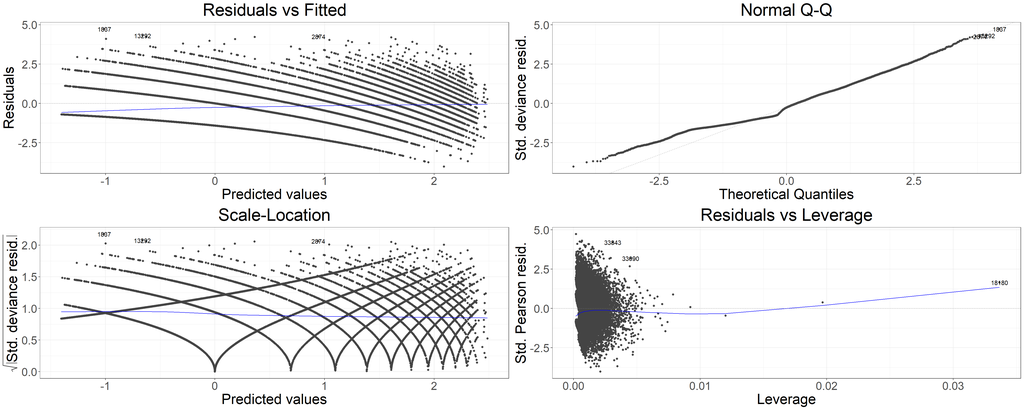

```r
# Plots
poisson_final %>% autoplot() + theme_custom
```

Overdispersion decreases from 1.54 to 1.14, and autocorrelation also decreases

```r
# Overdispersion
dispersiontest(poisson_m0)
```

```
##
##  Overdispersion test
##
## data:  poisson_m0
## z = 18.682, p-value < 2.2e-16
## alternative hypothesis: true dispersion is greater than 1
## sample estimates:
## dispersion
##   1.543548
```

```r
dispersiontest(poisson_m2)
```

```
##
##  Overdispersion test
##
## data:  poisson_m2
## z = 18.414, p-value < 2.2e-16
## alternative hypothesis: true dispersion is greater than 1
## sample estimates:
## dispersion
##   1.195742
```

```r
dispersiontest(poisson_final)
```

```
##
##  Overdispersion test
##
## data:  poisson_final
## z = 14.779, p-value < 2.2e-16
## alternative hypothesis: true dispersion is greater than 1
## sample estimates:
## dispersion
##   1.143892
```

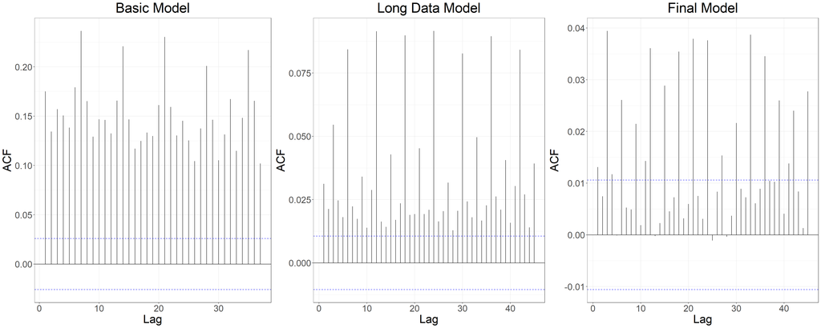

```r
# Autocorrelation of residuals
ggarrange (
residuals(poisson_m0, type = "response") %>% acf() %>% autoplot() +
  ggtitle("Basic Model") + theme_custom,
residuals(poisson_m2, type = "response") %>% acf() %>% autoplot() +
  ggtitle("Long Data Model") + theme_custom,
residuals(poisson_final, type = "response") %>% acf() %>% autoplot() +
  ggtitle("Final Model") + theme_custom,
nrow = 1
)
```

## Impact of Model Choice

Let’s return to the negative binomial regression and the use of robust standard errors for the Poisson regression on the final set of variables.

```r
# Poisson regression
tidy(poisson_final, conf.level = 0.95, conf.int = TRUE) %>%
  mutate(
    model = "Poisson") -> Poisson_data_final

# Heteroscedasticity-consistent estimation  (vcovHC)
bind_cols(
  tidy(coeftest(poisson_final, vcov. = vcovHC(poisson_final, type = "HC3"))),
  coefci(poisson_final, vcov. = vcovHC(poisson_final, type = "HC3")) %>%
    as_tibble() %>% rename(conf.low = "2.5 %", conf.high = "97.5 %")) %>%
  mutate(
    model = "Poisson_vcovHC") -> Poisson_vcovHC_data_final

# Heteroscedasticity and Autocorrelation Consistent estimation (vcovHAC)
bind_cols(
  tidy(coeftest(poisson_final, vcov. = vcovHAC(poisson_final))),
  coefci(poisson_final, vcov. = vcovHAC(poisson_final)) %>%
    as_tibble() %>% rename(conf.low = "2.5 %", conf.high = "97.5 %")) %>%
  mutate(
    model = "Poisson_vcovHAC") -> Poisson_vcovHAC_data_final

# Negative binomial regression
NBR_final <- glm.nb(EMS ~ Date + Day_Week + Sin_year +
                       Age*DayOff + Age*COVID + Age*Temp_mean +
                       Age*Sex + Sex*COVID + Sex*Temp_mean +
                       Wind + Sunspots + K_Sum + Dst_var,
                     data = brain_data_long_transform, link = "log")

tidy(NBR_final, conf.level = 0.95, conf.int = TRUE) %>%
  mutate(
    model = "Neg_binomial") -> Neg_binomial_data_final
```

The use of robust standard errors (vcovHC/vcovHAC) and negative binomial regression in the final model, compared to the baseline, has virtually no effect on the confidence intervals for the estimates, meaning that the use of Poisson regression was justified!

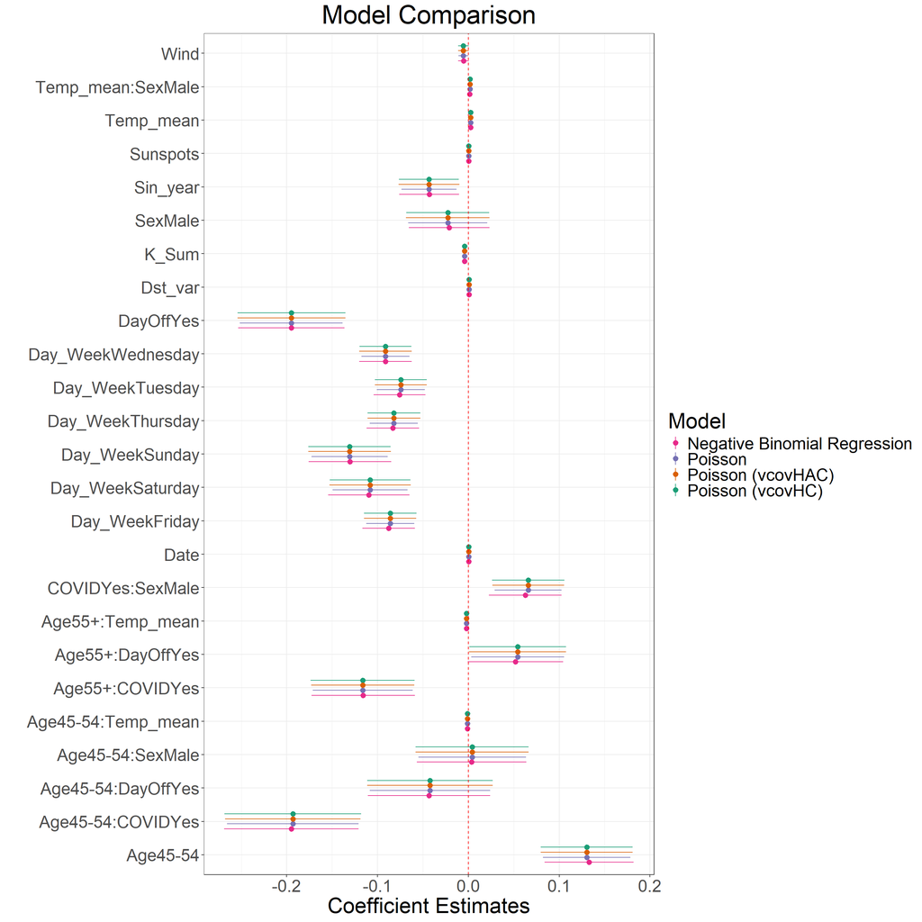

```r
bind_rows(Poisson_data_final, Poisson_vcovHC_data_final,
          Poisson_vcovHAC_data_final, Neg_binomial_data_final) %>%
  filter(between(estimate, -0.2, 0.2)) %>%
  mutate(
         model = fct_recode(model, `Poisson (vcovHC)` = "Poisson_vcovHC",
                           `Poisson (vcovHAC)`= "Poisson_vcovHAC",
                           `Negative Binomial Regression` = "Neg_binomial")) %>%
  ggplot(aes(x = term,y = estimate, ymin = conf.low, ymax = conf.high, colour = model))+
  geom_pointrange(position = position_dodge(width = 0.6)) +
  geom_hline(yintercept = 0, linetype = "dashed", color = "red") +
  scale_color_brewer(palette = "Dark2", direction = -1)+
  coord_flip() +
  labs( x = "", y = "Coefficient Estimates", title = "Model Comparison", color = "Model") +
  theme_custom
```

## EMS effect

```r
final_table <- tidy(poisson_final, conf.level = 0.95, conf.int = TRUE)
```

The table below presents the factors significantly associated with ambulance calls, derived from the final model.

```r
final_table %>%
  filter(p.value < 0.05, term != "(Intercept)") %>%
  transmute(
      Term = term, estimate = (exp(estimate) - 1) * 100,
      conf.low = (exp(conf.low) - 1) * 100, conf.high = (exp(conf.high) - 1) * 100) %>%
  gt() %>%
  fmt_number(columns = 2:4, decimals = 2) %>%
  tab_header(
    title = md("**Factors Associated with Ambulance Calls**"),
    subtitle = md("*Only significant associations (p < 0.05)*") ) %>%
  cols_label(
    Term = md("**Variable**"), estimate = md("*Estimate*"),
    conf.low = md("*Lower CI*"), conf.high = md("*Upper CI*") ) %>%
  tab_spanner(
    label = md("**Association, %**"),
    columns = c(estimate, conf.low, conf.high) ) %>%
  tab_options( row.striping.include_table_body = TRUE )
```

**Factors Associated with Ambulance Calls**

*Only significant associations (p < 0.05)*

| **Variable** | **Association, %** *Estimate* | **Association, %** *Lower CI* | **Association, %** *Upper CI* |
| --- | --- | --- | --- |
| Date | 0.03 | 0.03 | 0.03 |
| Day_WeekTuesday | −7.16 | −9.57 | −4.68 |
| Day_WeekWednesday | −8.71 | −11.10 | −6.27 |
| Day_WeekThursday | −7.88 | −10.28 | −5.41 |
| Day_WeekFriday | −8.24 | −10.63 | −5.78 |
| Day_WeekSaturday | −10.25 | −13.88 | −6.46 |
| Day_WeekSunday | −12.26 | −15.86 | −8.49 |
| Sin_year | −4.25 | −7.11 | −1.29 |
| Age45-54 | 13.92 | 8.58 | 19.53 |
| Age55+ | 714.31 | 684.76 | 745.19 |
| DayOffYes | −17.70 | −22.23 | −12.92 |
| COVIDYes | −18.98 | −23.42 | −14.31 |
| Temp_mean | 0.27 | 0.04 | 0.49 |
| Wind | −0.55 | −1.08 | −0.02 |
| Sunspots | 0.05 | 0.03 | 0.06 |
| K_Sum | −0.41 | −0.54 | −0.28 |
| Dst_var | 0.08 | 0.03 | 0.14 |
| Age55+:DayOffYes | 5.57 | 0.34 | 11.11 |
| Age45-54:COVIDYes | −17.57 | −23.32 | −11.39 |
| Age55+:COVIDYes | −10.99 | −15.73 | −5.94 |
| Age55+:Temp_mean | −0.20 | −0.37 | −0.03 |
| Age55+:SexMale | −40.27 | −42.96 | −37.45 |
| COVIDYes:SexMale | 6.81 | 2.96 | 10.81 |
| Temp_mean:SexMale | 0.17 | 0.06 | 0.28 |